# CPU DATA ANALYSIS .rmd

[MT2013 - CC09] Group 9

April 2023

# 1 Data Description

## 1.1 Preperation for code running

To start running code, first of all, we need to install some R packages, in which there are functions needed for our analysis and visualizing tasks.

```r
# Un-comment if your Rstudio do not have available these below packages

# install.packages('car')
# install.packages('caret')
# install.packages('dplyr')
# install.packages('drc')
# install.packages('ggplot2')
# install.packages('lessR')
# install.packages('randomForest')
# install.packages('readr')
# install.packages('nlme')
# install.packages('nls.multstart')
# install.packages('pacman')
# install.packages('readxl')
# install.packages('tidyverse')
```

We need to attach some libraries from installed packages to ensure that all functions below can run smoothly.

```r
library(car)
library(caret)
library(dplyr)
library(drc)
library(ggplot2)
library(lessR)
library(randomForest)
library(readr)
library(nlme)
library(nls.multstart)
library(pacman)
library(readxl)
library(tidyverse)
```

## 1.2 Importing data

From **https://www.kaggle.com/datasets/iliassekkaf/computerparts?select=Intel_CPUs.csv**, we can download the raw version of the data about CPU and put it in our working space.

Before importing data, it is needed to set up some indexes for p_load configuration.

```r
pacman::p_load(
               rio,     # for dealing with basic import export
               ggplot2, # for dealing with plot formats
               zoo      # for dealing with year quarter formats
)
```

Then we set the working directory and import the raw data file from it.

```r
# Import data
setwd("C:/ACA/PnS_Project/Data")
data <- import("./cpu-raw.csv")       # rio::import
```

We select the necessary columns being are useful for building models and prediction. All of the remaining columns will be removed since they contribute little on our analysis working.

**Need columns**: Vertical segment, Status, Launch date, Lithography, Recommended Customer price, Number of cores, Processor base frequency, Thermal design power and Temperature.

Changing variable names play an important role in our project, so that it is more convenient and easier to modify the code instead of dealing with the their long names. After that we export this file *cpu-short.csv* into the set working directory.

```r
#Data attribute selection
data <- data[, c("Vertical_Segment", "Status", "Launch_Date", "Lithography",
                 "Recommended_Customer_Price", "nb_of_Cores",
                 "Processor_Base_Frequency", "TDP","T")]

# Rename labels - easier to use
names(data) <- c("market", "status", "ldate", "litho", "rprice", "ncore", "bfreq", "tdp", "temp")
names(data)
```

```
## [1] "market" "status" "ldate"  "litho"  "rprice" "ncore"  "bfreq"  "tdp"
## [9] "temp"
```

```r
export(data, "cpu-short.csv")
```

## 1.3 Cleaning data

After successfully importing data into working directory with some pre-processing steps, we continue to use *cpu-short.csv* file to clean.

First, we import *cpu-short.csv* file created from the last section.

```r
data <- import('cpu-short.csv')
```

**Launched date** (ldate) column: we change it into the standard form with `as.yearqtr()` command.

```r
data[,"ldate"] <- (
  as.yearqtr(data[,"ldate"], format = "Q%q'%y")
)
```

**Recommended Customer Price** Some rprice values have ranges instead of sole numbers. We want to cut out unnecessary characters and only keep the largest price. After that, we eliminate $ symbol from the string, as well as cast the string to numeric type

```r
data[,"rprice"] <- gsub("(^\\$(\\d)+.(\\d)+ - )", "", data[,"rprice"])
data$rprice <- ifelse(data$rprice == "N/A", NA, data$rprice)

data$rprice <- as.numeric(gsub('\\$|,', '', data$rprice))
```

**Temperature** Our goal is to only match the numeric values, then, take the maximum among those. The approach to processing the complicated strings in temp is described as follows:

First, we attempt to match every decimal numbers possible, including the irrelevant number. The rest are replaced with commas “,”. The result of this process will create a string of numbers separated by commas. By doing this, the numbers are well isolated for our purpose.

Second, we split these numbers and form a vector of them. This can be done through strsplit function. Notice that our numbers are still in string format.

Third, we cast all these strings to numeric and push them into a vector of values using unlist and lapply

Fourth, we find the maximum among all these values. Invalid numbers will automatically become −∞, and will be further treated as NA.

Notice that, we must loop through each row of the list to accomplish the above procedure.

```r
data[,"temp"] <- (gsub("[^0-9.\\-]+", ",", data[,"temp"]))  #
for (i in seq_along(data[["temp"]])) {                    # For each elements in the same entry
  temp_values <- strsplit(data[i, "temp"], ",")           # Split into a list of words
  temp_values <- unlist(lapply(temp_values, as.numeric))  # Transform them into equivalent numerics
  max_value <- max(temp_values, na.rm = TRUE)             # Find max
  if (is.infinite(max_value)) {                           # Is it an invalid numeric?
    max_value <- NA
  }
  data[i, "temp"] <- max_value                            # Store the maximum value
}
```

With the **others columns**, we only remove the their units and turn it from *string type* into *numeric type* that can be used for plotting or calculating purposes.

```r
data[,"litho"] <- as.numeric(gsub(" nm", "", data[,"litho"]))
data[,"tdp"] <- as.numeric(gsub(" W", "", data[,"tdp"]))

data[,"bfreq"] <- as.numeric(gsub("( GHz)|( MHz)", "",data[,"bfreq"]))
data<- data[!is.na(data$bfreq), ]   # Truncate NAs because subscripting with NA is not allowed.
data$bfreq[data$bfreq > 10] <- data$bfreq[data$bfreq > 10]*0.001
```

Finally, the data frame is totally clean and can be used for following steps. It will then be export to the current directory.

```r
export(data, "cpu-clean.csv")
```

**In conclusion**, our data go through several processing steps:

- Raw data: the original data from website
- Short data: with only needed column and modified names for convenient using.
- Clean data: all of column values are change into numeric value instead of the raw string type. Some of them are brought to the standard forms.

# 2 DATA CLARIFICATION

Loading packages and Importing data

```r
pacman::p_load(
  rio,     # for imports & exports
  ggplot2, # for plots
  zoo,      # for year-quarter formats
  car,     # for levent and shapiro
  FSA,     # for Dunn test
)

#  IMPORT THE DATA
data <- import("cpu-clean.csv")        # rio::import
```

Box-plotting between **Lithography** (litho) and its **Launched date** (ldate).

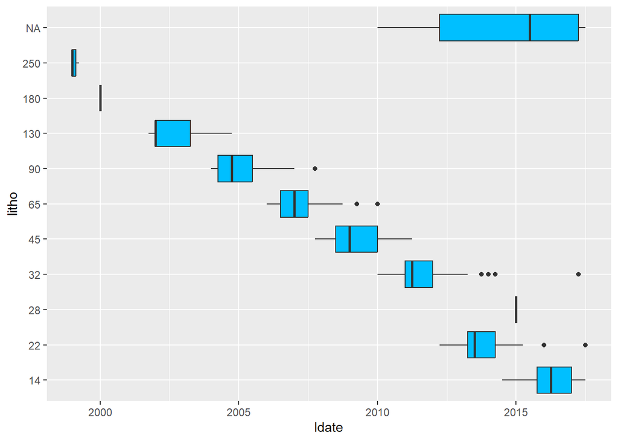

```r
data$litho <- as.factor(data$litho)
ggplot(data, aes(x = ldate, y = litho)) +
  geom_boxplot(fill = "deepskyblue")
```

Scatter-plotting between **Lithography** (litho) and its **Launched date** (ldate).

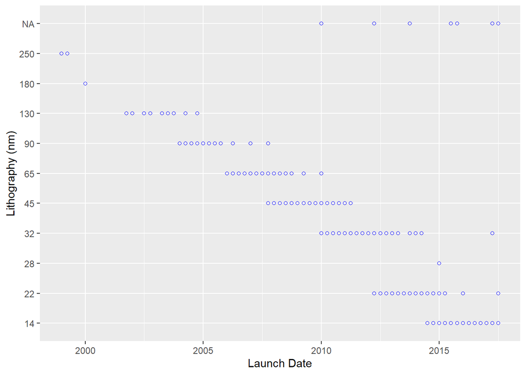

```r
ggplot(data, aes(x = ldate, y = litho)) +
geom_point(shape = 1,color = "blue") +
labs(x = "Launch Date", y = "Lithography (nm)")
```

Box-plotting of Thermal design power in 4 markets

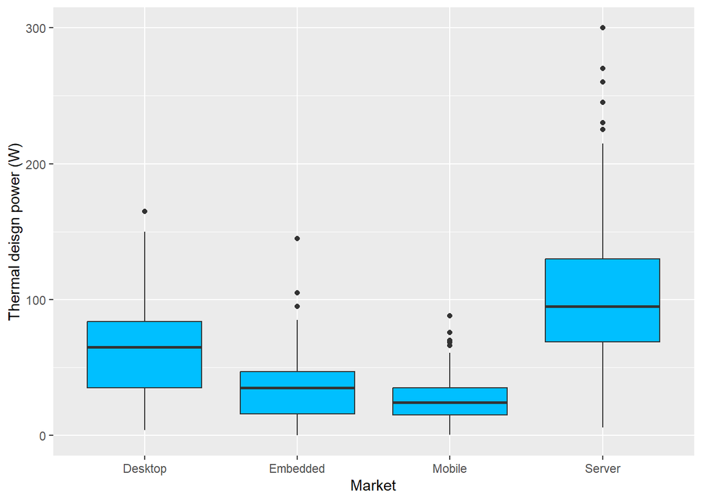

```r
ggplot(data, aes(x = market,y = tdp)) +
geom_boxplot(fill = "deepskyblue") +
labs(x = "Market", y = "Thermal deisgn power (W)")
```

```r
summary(data$tdp)
```

```
##    Min. 1st Qu.  Median    Mean 3rd Qu.    Max.    NA's
##   0.025  25.000  47.000  60.242  85.000 300.000      49
```

Histogram of Thermal Design Power

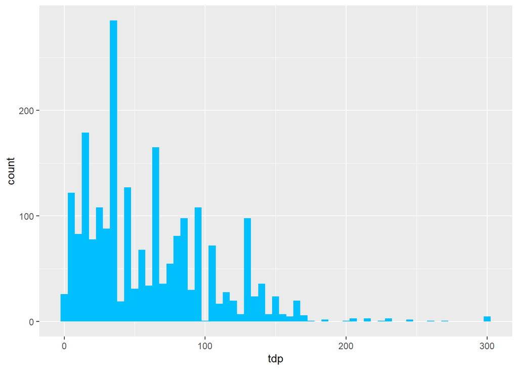

```r
ggplot(data, aes(x = tdp)) +
  geom_histogram(binwidth = 5, fill = "deepskyblue")
```

```r
summary(data$tdp)
```

```
##    Min. 1st Qu.  Median    Mean 3rd Qu.    Max.    NA's
##   0.025  25.000  47.000  60.242  85.000 300.000      49
```

```r
plot_data <- data
plot_data$ncore <- as.factor(plot_data$ncore)
```

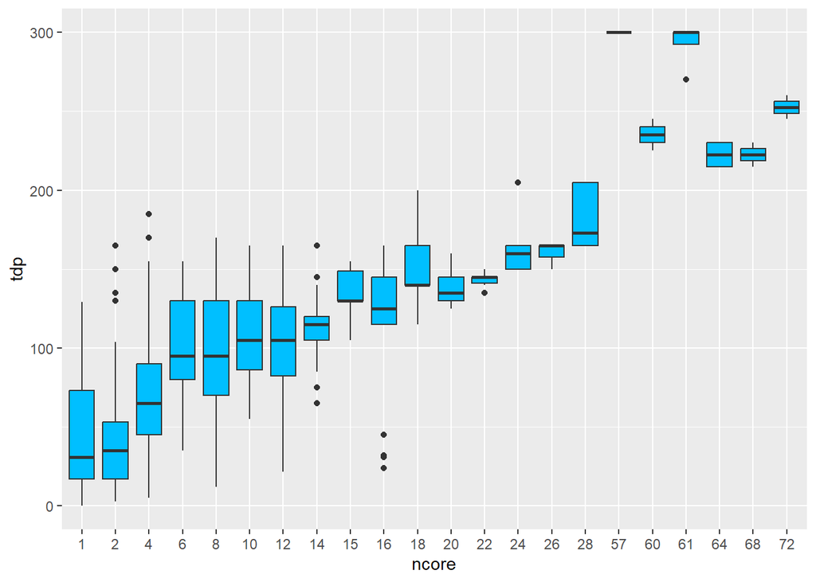

```r
ggplot(plot_data, aes(x = ncore, y = tdp)) + geom_boxplot(fill = "deepskyblue")
```

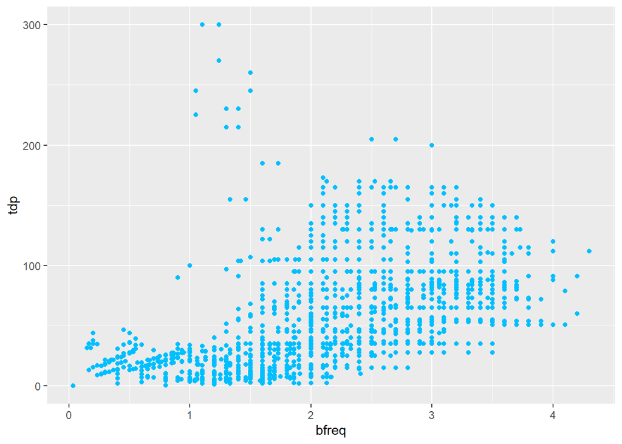

```r
# Base frequqency is a bit random, but the trend of linearity is still evident
ggplot(plot_data, aes(x = bfreq, y = tdp)) + geom_point(color = "deepskyblue")
```

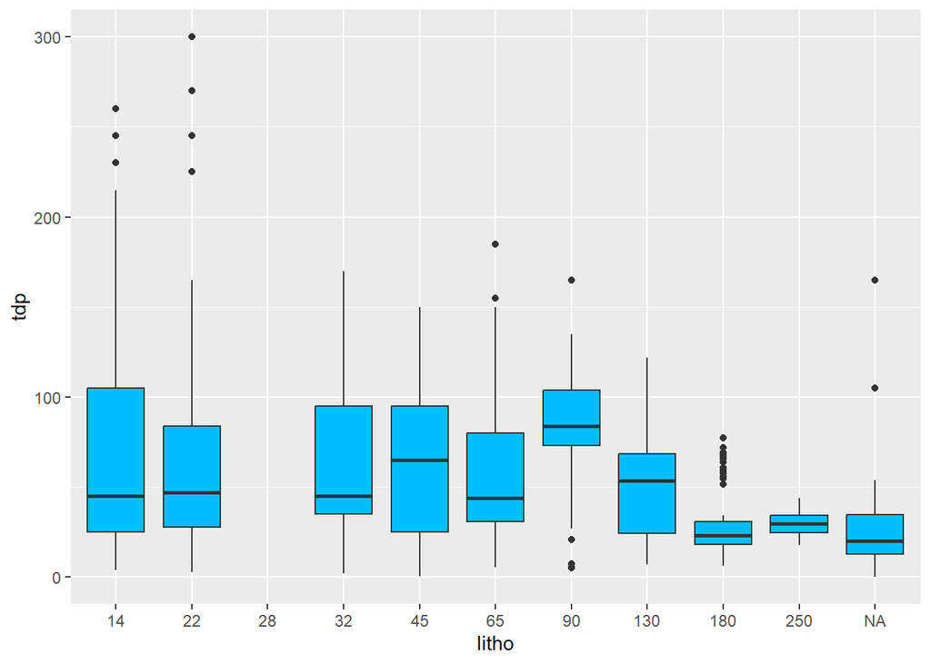

```r
plot_data$litho <- as.factor(plot_data$litho)

# Lithography as tdp is less convincing; however, we see that recent lithography techniques tend to have stable base frequency
ggplot(plot_data, aes(x = litho, y = tdp)) + geom_boxplot(fill = "deepskyblue")
```

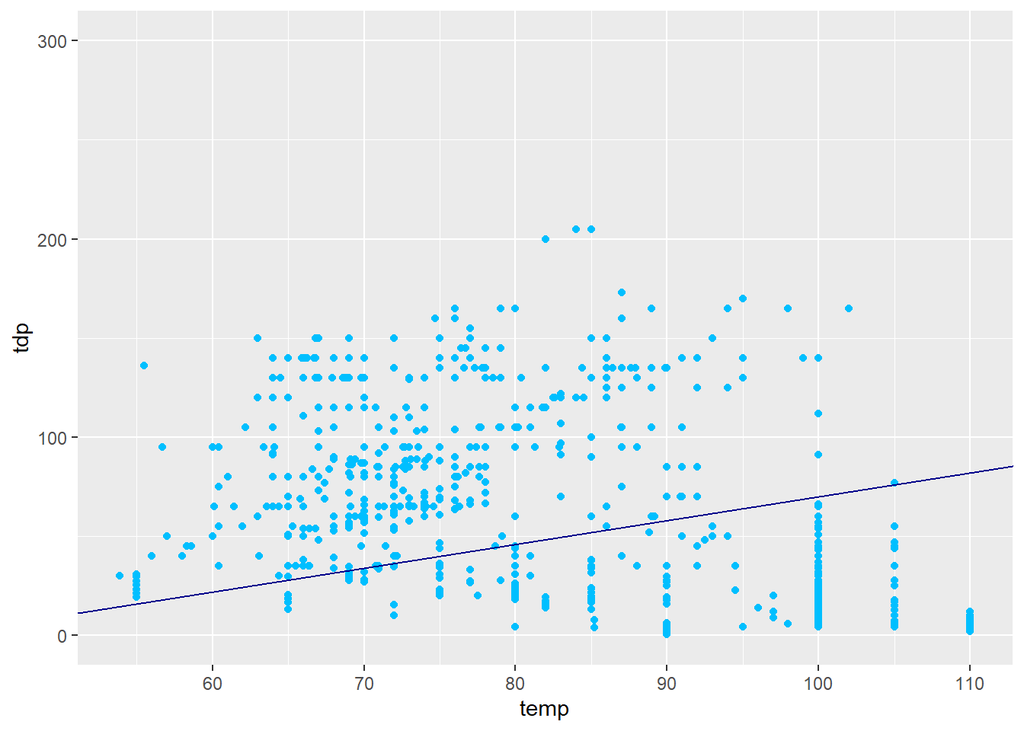

```r
# Different trends
ggplot(plot_data, aes(x = temp, y = tdp)) +
  geom_point(color = "deepskyblue", ) +
  geom_abline(mapping = aes(intercept= -50, slope = 1.2), color = "darkblue")
```

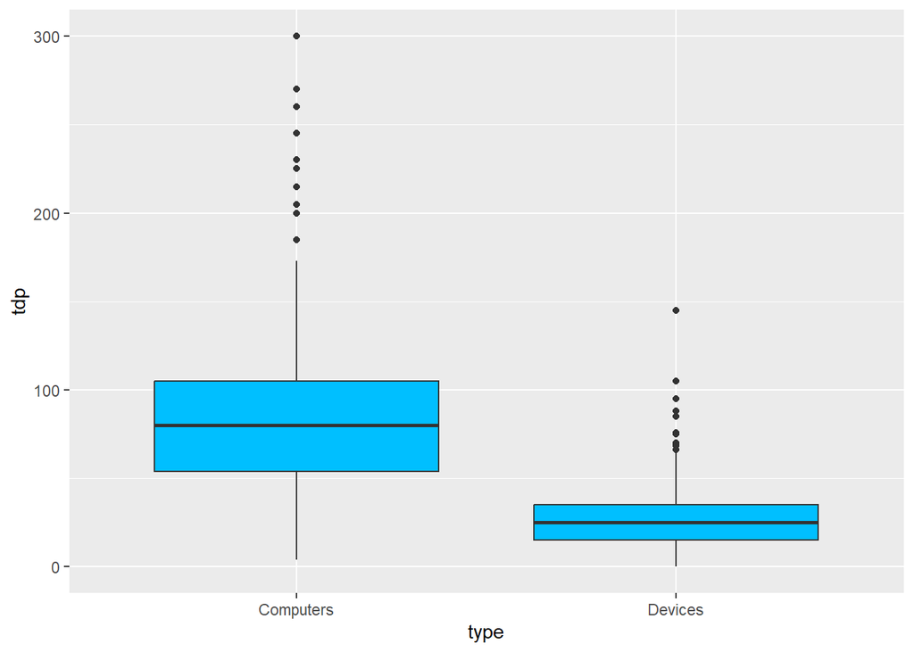

```r
data$type <- ifelse(data$market == 'Server' | data$market == 'Desktop', "Computers", "Devices")
data$type <- as.factor(data$type)

ggplot(data, aes(x = type, y = tdp)) + geom_boxplot(fill = "deepskyblue")
```

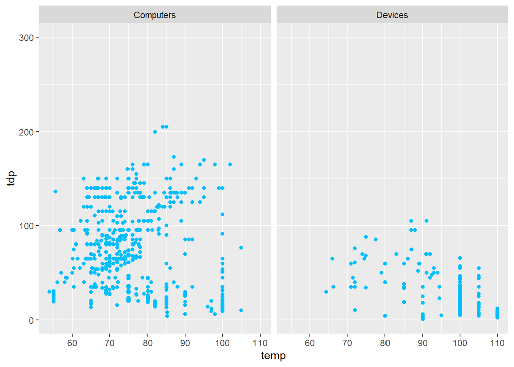

```r
ggplot(data, aes(x = temp, y = tdp)) + geom_point(color = "deepskyblue", ) + facet_wrap(~data$type)
```

# 3 DATA ANALYSIS

## 3.1 Data preparation

```r
pacman::p_load(
  rio,            # for imports & exports
  ggplot2,        # for plots
  zoo             # for year-quarter formats
)

data <- import("cpu-clean.csv") # rio::impor
```

```r
data <- data[data$tdp < 150, ]
data <- data[!is.na(data$tdp), ]
data <- data[!is.na(data$bfreq), ]
data <- data[!is.na(data$litho), ]
data <- data[!is.na(data$ncore), ]
data <- data[!is.na(data$temp), ]
```

## 3.2 Splitting data into train set and validated set

Before building models for prediction, we must separate data into 2 data set: *train set* and *validated set (test set)*. **80% data is used for train set, while the remaining 20% data is used for test set.**

```r
# Set default seed for random
set.seed(123)

#Use 80% of data frame as training set and 20% as test set
train_indices <- sample(1:nrow(data), nrow(data) * 0.8)
train <- data[train_indices, ]
test <- data[-train_indices, ]
```

## 3.3 The relationships between TDP and other factors

### 3.3.1 Lithography as a CPU eras

In this small section, we will demonstrate why **Lithography as a better representative than Launch date**. To do that, we start by looking at the confidence interval and the visualizations of Lithography over the years.

```r
data$litho <- as.factor(data$litho)

retval <- data.frame(NA, NA, NA, NA)
names(retval) <- c("5% quantile","95% quantile", "STD Mean", "Confidence Interval")

for (lit in levels(data$litho))
{
  quants <- quantile(
    data[data$litho == lit, ]$ldate,
    na.rm = T,
    probs = c(0.05,0.95)
  )

  dates <- data[data$litho == lit, ]$ldate

  new_row <- data.frame(quants[1], quants[2], mean(sd(dates, na.rm=TRUE),
  na.rm=TRUE),quants[2]-quants[1])

  names(new_row)<-c("5% quantile","95% quantile", "STD Mean", "Confidence Interval")

  retval <- rbind(retval, new_row)
  rm(dates)
}

rownames(retval) <- c("NULL", levels(data$litho))
retval <- retval[-1,]

print(retval)
```

```
##     5% quantile 95% quantile  STD Mean Confidence Interval
## 14      2015.00     2017.500 0.8640376              2.5000
## 22      2012.25     2015.000 0.8159340              2.7500
## 32      2010.00     2012.500 0.9585590              2.5000
## 45      2007.75     2010.500 0.8603672              2.7500
## 65      2006.00     2008.312 0.7363130              2.3125
## 90      2004.00     2007.750 1.0586129              3.7500
## 130     2001.75     2004.250 0.9025055              2.5000
## 180     2000.00     2000.000 0.0000000              0.0000
## 250     1999.00     1999.225 0.1443376              0.2250
```

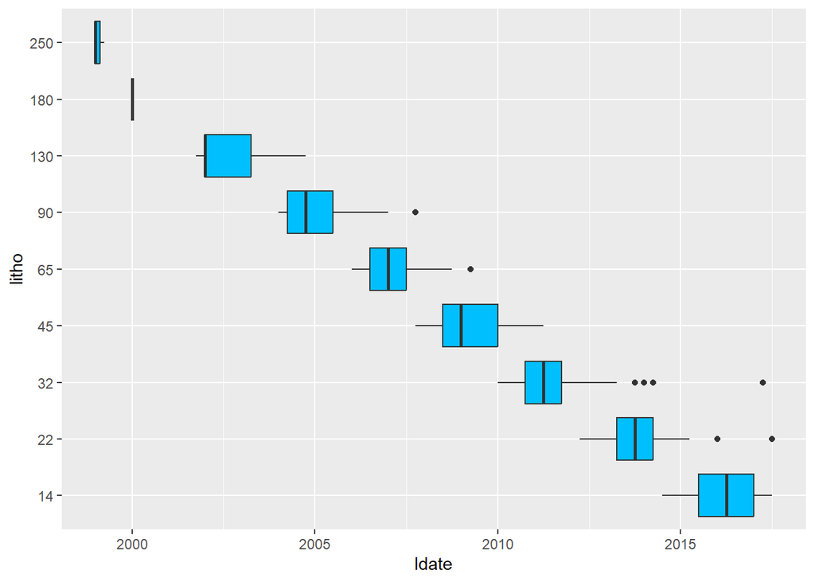

```r
ggplot(data, aes(x = ldate, y = litho)) + geom_boxplot(fill = "deepskyblue")
```

### 3.3.2 Thermal Design Power with respect to Lithography

```r
 # remove data with few count group ldate and remove NA
data <- data[data$litho !=28, ]
data <- data[data$litho !=250, ]

data <- data[!is.na(data$tdp), ]
data <- data[!is.na(data$litho), ]
```

We will creat a **ANOVA model**

```r
litho_anova_model <- aov(tdp ~ litho, data = data)
summary(litho_anova_model)
```

```
##               Df  Sum Sq Mean Sq F value              Pr(>F)
## litho          7  153527   21932   15.62 <0.0000000000000002 ***
## Residuals   1860 2612315    1404
## ---
## Signif. codes:  0 '***' 0.001 '**' 0.01 '*' 0.05 '.' 0.1 ' ' 1
```

We can see that as the p-value < 0.05, we can reject the null hypothesis H0 and accept the alternative hypothesis H1 that there exist a pair of lithography type so that their TDP mean is difference.

To satisfy the requirements of One-way ANOVA, we should check its assumptions on Normality and Homoscedasticity (homogeneous variance)

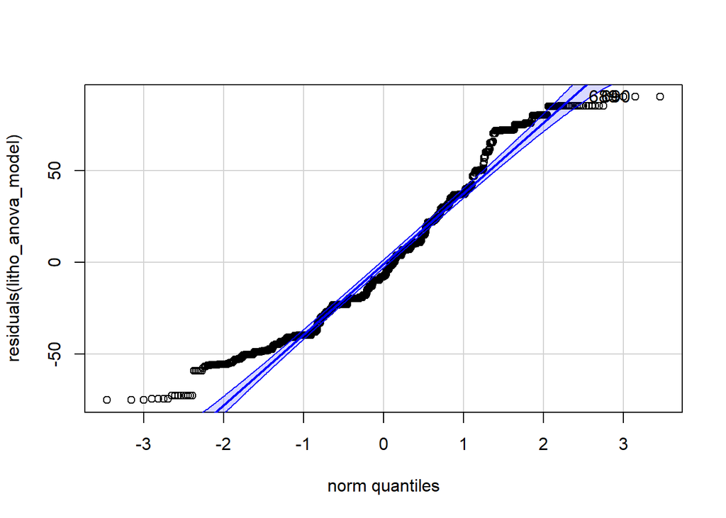

```
## 689 690
## 545 546
```

```r
qqPlot(residuals(litho_anova_model))
```

```r
shapiro.test(residuals(litho_anova_model))
```

```
##
##  Shapiro-Wilk normality test
##
## data:  residuals(litho_anova_model)
## W = 0.95795, p-value < 0.00000000000000022
```

```r
leveneTest(tdp ~ litho, data = data)
```

```
## Levene's Test for Homogeneity of Variance (center = median)
##         Df F value              Pr(>F)
## group    7    11.6 0.00000000000001673 ***
##       1860
## ---
## Signif. codes:  0 '***' 0.001 '**' 0.01 '*' 0.05 '.' 0.1 ' ' 1
```

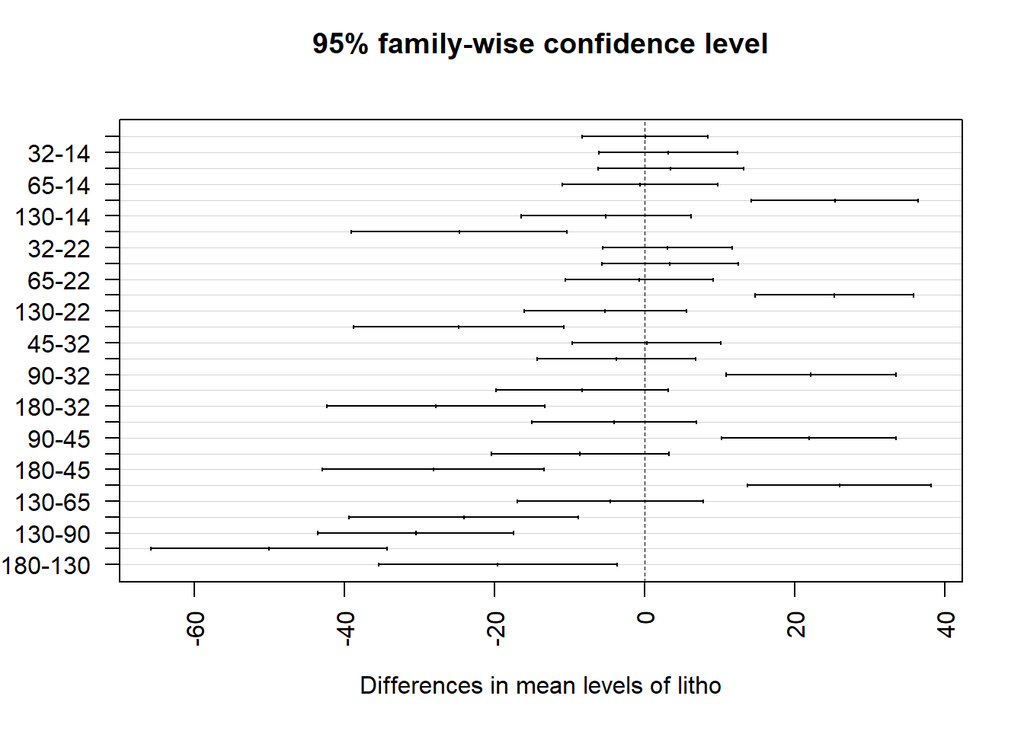

```r
Tukey<-TukeyHSD(litho_anova_model)
plot(Tukey,las = 2)
```

```r
dunnTest(tdp ~ litho, data = data,method = "bonferroni")
```

```
##    Comparison           Z                       P.unadj
## 1    130 - 14 -0.21389365 0.830629994245332459179564921
## 2   130 - 180  4.13700975 0.000035186116711256129488492
## 3    14 - 180  4.74252636 0.000002110693497127046037391
## 4    130 - 22 -1.10980635 0.267082483004157267281186705
## 5     14 - 22 -1.13976118 0.254385810307202475666343844
## 6    180 - 22 -5.56381490 0.000000026393990967043478386
## 7    130 - 32 -1.91282346 0.055770657165341831762450653
## 8     14 - 32 -2.11076370 0.034792627795381912692018744
## 9    180 - 32 -6.04322872 0.000000001510602715075547576
## 10    22 - 32 -1.16042811 0.245874545817109463330396579
## 11   130 - 45 -1.67525316 0.093884571459170340634869945
## 12    14 - 45 -1.79522407 0.072618007423670499766998887
## 13   180 - 45 -5.78224776 0.000000007370904119388734210
## 14    22 - 45 -0.86625686 0.386349316706033729662550513
```

[output cut: 43 more lines]

## 3.4 Regression analysis

### 3.4.1 Multi-linear Regression model

Due to the relationship between **Thermal design power** (tdp) with other variables, expressed by scatter-plotting graphs *(in report)*, it can be seen that they may related to **Linear regression**.

To start with, we build a linear regression model using command `lm()`, and give the information about this model by `summary()`.

```r
# Build the model
model.lr <- lm(tdp ~ ncore + bfreq + temp , data = train)

# Summary of the model
summary(model.lr)
```

```
##
## Call:
## lm(formula = tdp ~ ncore + bfreq + temp, data = train)
##
## Residuals:
##     Min      1Q  Median      3Q     Max
## -68.762 -10.988   0.042  10.892  90.943
##
## Coefficients:
##             Estimate Std. Error t value            Pr(>|t|)
## (Intercept)  89.8963     4.2994   20.91 <0.0000000000000002 ***
## ncore         5.0355     0.1599   31.49 <0.0000000000000002 ***
## bfreq        17.9753     0.7549   23.81 <0.0000000000000002 ***
## temp         -1.0745     0.0380  -28.28 <0.0000000000000002 ***
## ---
## Signif. codes:  0 '***' 0.001 '**' 0.01 '*' 0.05 '.' 0.1 ' ' 1
##
## Residual standard error: 20.43 on 1505 degrees of freedom
## Multiple R-squared:  0.7178, Adjusted R-squared:  0.7172
## F-statistic:  1276 on 3 and 1505 DF,  p-value: < 0.00000000000000022
```

We can observe that all of the variables have the p-value less than 0.05, therefore; all predictors that we have chosen is involved in the building process.

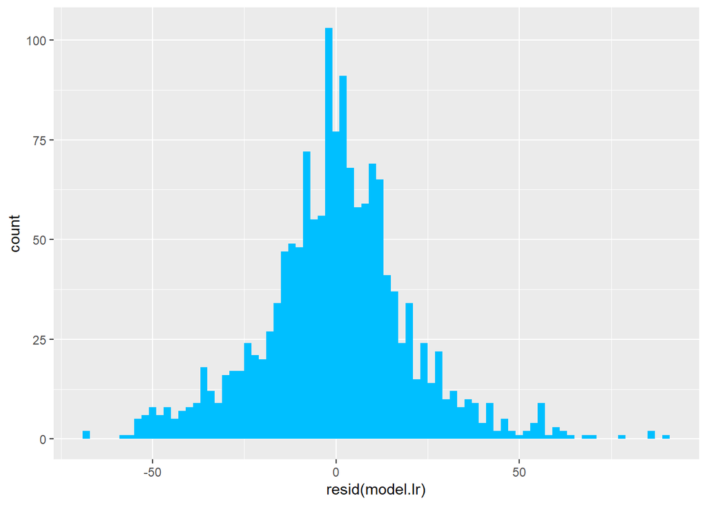

```r
# Plotting residuals' histogram
ggplot(model.lr, aes(x = resid(model.lr))) +
  geom_histogram(binwidth = 2, fill = "deepskyblue")
```

We can check assumption: Residual Errors have Constant Variance by using the Scale-Location plot.

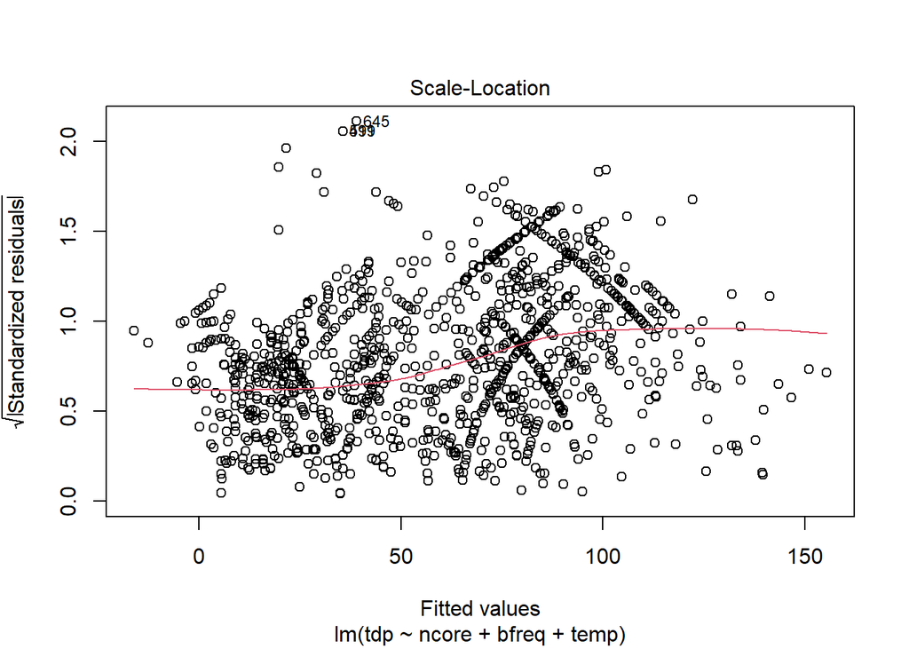

```r
plot(model.lr, which = 3)
```

To test if the residuals is normally distributed, we plot the Q-Q plot using the command `plot()`.

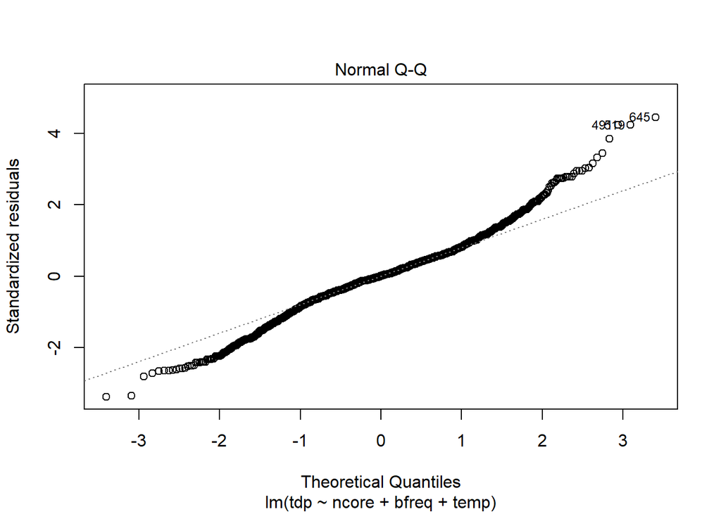

```r
plot(model.lr, which = 2)
```

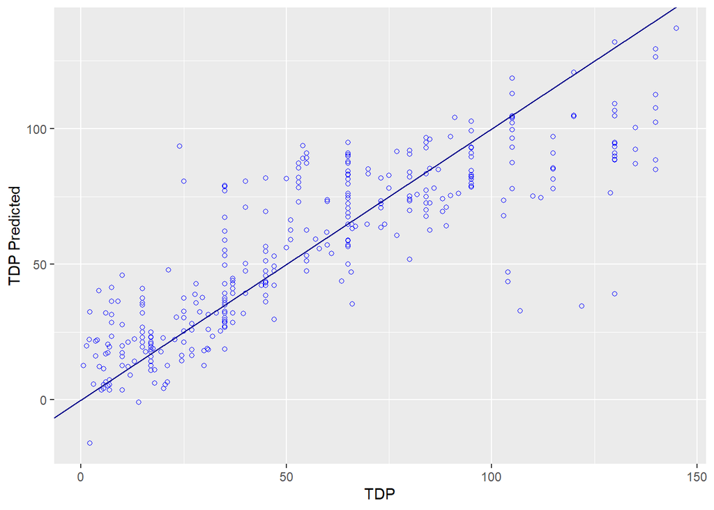

```r
# Create data frame for actual tdp value and predicted tdp value
comtab.lr <- test['tdp']
comtab.lr['tdp_predicted'] <- as.data.frame(predict(model.lr, newdata = test), row.names = NULL)

# Plotting
# The majority of points lie near the line, so it is fine.
ggplot(comtab.lr, aes(x = tdp, y = tdp_predicted)) +
  geom_point(shape=1, color="blue") +
  geom_abline(mapping=aes(intercept= 0, slope=1), color="darkblue") +
  labs(x = "TDP", y = "TDP Predicted")
```

### 3.4.2 Random forest regression model

In this section, we will introduce Random Forest regression model. In fact, random forest models are often used for predicting system performance metrics such as CPU usage, response time, and throughput. The algorithm can handle both continuous and categorical data, making it a suitable choice for modeling CPU attribute data that may contain a mix of numerical and categorical variables.

First, we build the **Random Forest Regression model** with `randomForest()`.

```r
# Build the model
model.rfr <- randomForest(formula = tdp ~ bfreq + ncore + temp, data = train, ntree = 500)

# Print the model
print(model.rfr)
```

```
##
## Call:
##  randomForest(formula = tdp ~ bfreq + ncore + temp, data = train,      ntree = 500)
##                Type of random forest: regression
##                      Number of trees: 500
## No. of variables tried at each split: 1
##
##           Mean of squared residuals: 202.6334
##                     % Var explained: 86.27
```

Another method to test the fitness of this model is checking the **Mean Absolute Error** (MAE) of this model. The lower the MAE, the better this model validates our hypothesis. To check MAE, using the following commands.

```r
# Create data frame for real tdp value and predicted tdp value
comtab.rfr <- test['tdp']
comtab.rfr['tdp_predicted'] <- as.data.frame(predict(model.rfr, newdata = test), row.names = NULL)

# Evaluate model performance
accuracy <- sum(1-abs(comtab.rfr$tdp_predicted - comtab.rfr$tdp) / comtab.rfr$tdp) / nrow(comtab.rfr)
MAE <- sum(abs(comtab.rfr$tdp_predicted - comtab.rfr$tdp)) / nrow(comtab.rfr)

print(paste("Accuracy:", accuracy))
```

```
## [1] "Accuracy: 0.462070680241123"
```

```r
print(paste("MAE:", MAE))
```

```
## [1] "MAE: 10.4861167880433"
```

Similarly with the R-squared validation, to compute the R-squared value, we use the following commands

```r
# Calculate R-squared on testing data
r2_test <- cor(comtab.rfr$tdp, comtab.rfr$tdp_predicted)^2
print(r2_test)
```

```
## [1] 0.861954
```

Because the assumption of this Random Forest model requires that the residual must follow normal distribution, we will use Q-Q plot to test if the residuals is normally distributed:

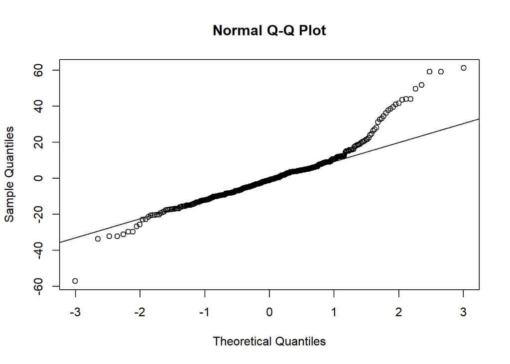

```r
# Calculate the residuals by subtracting the actual values from the predicted values
residuals <- comtab.rfr$tdp - comtab.rfr$tdp_predicted

# Create a normal probability plot of the residuals
qqnorm(residuals)
qqline(residuals)
```

In the Q-Q plot, it can be seen that those points are not fully lying near the line. We can conclude that this model may not be normally accurate.

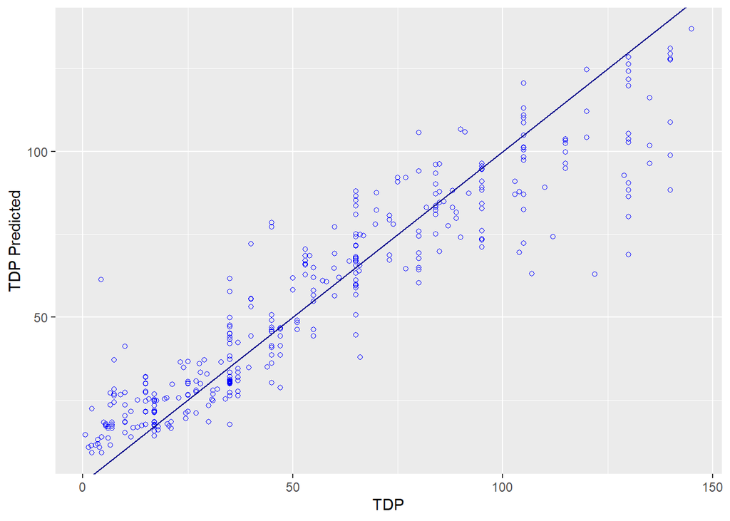

```r
# Plotting the predicted - actual
ggplot(comtab.rfr, aes(x = tdp, y = tdp_predicted)) +
  geom_point(shape=1, color="blue") +
  geom_abline(mapping=aes(intercept= 0, slope=1),color="darkblue") +
  labs(x = "TDP", y = "TDP Predicted")
```

## 3.5 Classification problem

### 3.5.1 Logistic Regression Model

Logistic Regression is a type of statistical analysis that is used to model and predict the probability of a binary outcome based on one or more predictor variables. It is a type of supervised learning algorithm that is commonly used in machine learning and data analysis.

Now, we will label each with corresponding type 1 or 0; 1 for market Desktop or Server and 0 for the rest:

```r
# Add Type column
# Server or Desktop will be in type 1, otherwise type 0
train$type <- ifelse(train$market == 'Server' | train$market == 'Desktop', 1, 0)
test$type <- ifelse(test$market == 'Server' | test$market == 'Desktop', 1, 0)
```

Then, we will build the logistic model for train set and make prediction on test set.

```r
# Model
model.l <- glm(type ~ tdp, data = train, family = 'binomial')

# Make predictions on the test data
predicted_probs <- predict(model.l, newdata = test, type = "response")
predicted_classes <- ifelse(predicted_probs > 0.5, 1, 0)
```

Now, when evaluating the performance of a logistic regression model, we use confusion matrix. The **confusion matrix** provides a summary of the number of correct and incorrect predictions made by the model, and is constructed by comparing the predicted values of the model with the actual values of the dependent variables.

To do that, we firstly convert the predicted classes and actual classes to factors with the same levels and labels. In the next stage, we continue to create a confusion matrix with command `confusionMatrix()`.

```r
# Evaluate model performance
predicted_classes_factor <- factor(predicted_classes, levels = c(0, 1), labels = c("Negative", "Positive"))
actual_classes_factor <- factor(test$type, levels = c(0, 1), labels = c("Negative", "Positive"))

# Create a confusion matrix
conf_matrix <- confusionMatrix(predicted_classes_factor, actual_classes_factor)
```

Then, we express it out with these below commands

```r
# Print the confusion matrix
print(conf_matrix)
```

```
## Confusion Matrix and Statistics
##
##           Reference
## Prediction Negative Positive
##   Negative      131       39
##   Positive       41      167
##
##                Accuracy : 0.7884
##                  95% CI : (0.7437, 0.8285)
##     No Information Rate : 0.545
##     P-Value [Acc > NIR] : <0.0000000000000002
##
##                   Kappa : 0.5729
##
##  Mcnemar's Test P-Value : 0.911
##
##             Sensitivity : 0.7616
##             Specificity : 0.8107
##          Pos Pred Value : 0.7706
##          Neg Pred Value : 0.8029
##              Prevalence : 0.4550
##          Detection Rate : 0.3466
##    Detection Prevalence : 0.4497
##       Balanced Accuracy : 0.7862
##
##        'Positive' Class : Negative
##
```

```r
# Print performance metrics
print(paste("Accuracy:", conf_matrix$overall['Accuracy']))
```

```
## [1] "Accuracy: 0.788359788359788"
```

```r
print(paste("Precision:", conf_matrix$byClass['Pos Pred Value']))
```

```
## [1] "Precision: 0.770588235294118"
```

```r
print(paste("Recall:", conf_matrix$byClass['Sensitivity']))
```

```
## [1] "Recall: 0.761627906976744"
```

```r
print(paste("F1 score:", conf_matrix$byClass['F1']))
```

```
## [1] "F1 score: 0.766081871345029"
```

To use a confusion matrix to evaluate the performance of a logistic regression model, the first step is to use the model to make predictions on a test data set that was not used to train the model. Then, the predicted values of the model are compared to the actual values of the dependent variable, and a confusion matrix is constructed.